# Gaussian Distributions: Sum and Product

## Introduction

In probability theory, the sum and product of Gaussian distributions exhibit interesting properties. In this notebook, we explore the mathematical concepts and visualize the distributions using Python.

## Sum of Gaussian Distributions

Consider two independent Gaussian distributions (X \sim \mathcal{N}(\mu_1, \sigma_1^2)) and (Y \sim \mathcal{N}(\mu_2, \sigma_2^2)). The sum of these distributions, (Z = X + Y), follows another Gaussian distribution with the following characteristics:

[ \mu_z = \mu_1 + \mu_2 ]

[ \sigma_z^2 = \sigma_1^2 + \sigma_2^2 ]

Let's visualize this concept with Python and matplotlib.

```python

# Code for visualizing the sum of Gaussian distributions

# ...

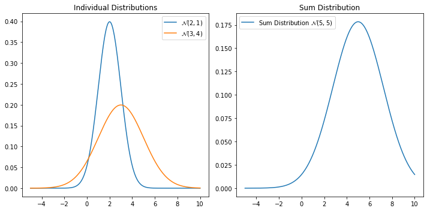

```python
import numpy as np
import matplotlib.pyplot as plt
from scipy.stats import norm

# Parameters for the distributions
mu1, sigma1 = 2, 1
mu2, sigma2 = 3, 2  # using sqrt(4) for standard deviation

# Generate data points for the distributions
x = np.linspace(-5, 10, 1000)
pdf_x = norm.pdf(x, mu1, sigma1)
pdf_y = norm.pdf(x, mu2, sigma2)

# Plot the individual distributions
plt.figure(figsize=(10, 5))

plt.subplot(1, 2, 1)
plt.plot(x, pdf_x, label=r'$\mathcal{N}(2, 1)$')
plt.plot(x, pdf_y, label=r'$\mathcal{N}(3, 4)$')
plt.title('Individual Distributions')
plt.legend()

# Plot the sum distribution
plt.subplot(1, 2, 2)
pdf_sum = norm.pdf(x, mu1 + mu2, np.sqrt(sigma1**2 + sigma2**2))
plt.plot(x, pdf_sum, label=r'Sum Distribution $\mathcal{N}(5, 5)$')
plt.title('Sum Distribution')
plt.legend()

plt.tight_layout()
plt.show()
```

## Product of Gaussian Distributions (Continued)

The convolution operation is more complex, and visualizing it directly can be challenging. We will use numerical methods to demonstrate this concept.

```python

# Code for visualizing the product of Gaussian distributions (convolution)

# ...

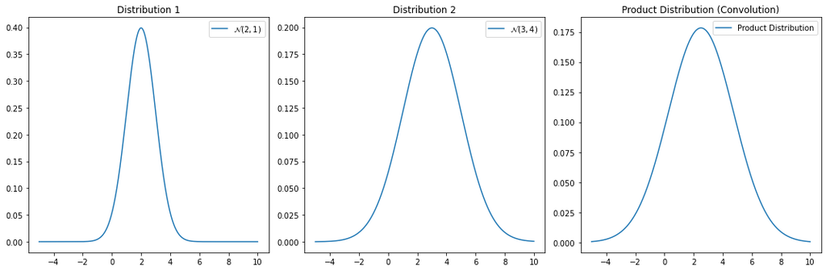

```python
import numpy as np
import matplotlib.pyplot as plt
from scipy.stats import norm

# Parameters for the distributions
mu1, sigma1 = 2, 1
mu2, sigma2 = 3, 2

# Generate data points for the distributions
x = np.linspace(-5, 10, 1000)
pdf_x = norm.pdf(x, mu1, sigma1)
pdf_y = norm.pdf(x, mu2, sigma2)

# Plot the individual distributions
plt.figure(figsize=(15, 5))

plt.subplot(1, 3, 1)
plt.plot(x, pdf_x, label=r'$\mathcal{N}(2, 1)$')
plt.title('Distribution 1')
plt.legend()

plt.subplot(1, 3, 2)
plt.plot(x, pdf_y, label=r'$\mathcal{N}(3, 4)$')
plt.title('Distribution 2')
plt.legend()

# Plot the product distribution (convolution)
pdf_product = np.convolve(pdf_x, pdf_y, mode='same') / np.sum(pdf_x)
plt.subplot(1, 3, 3)
plt.plot(x, pdf_product, label='Product Distribution')
plt.title('Product Distribution (Convolution)')
plt.legend()

plt.tight_layout()
plt.show()
```